# WS06

Note: Question 1 to 6 are answered in the notebook along the development of the model.

Report content is in the other PDF file, which covers the topic required by the workshop guideline, inlcuding:

- Which transactions are considered for association rule mining and why?
- Brief description of the analysis and pre-processing performed and reason why these processes are required (e.g., it’s impact on the results)?
- Discussion and interpretation of the results.
- Think of overall presentation and reference, use of Harvard referencing format as appropriate (not included in word limit).

```python
import matplotlib.pyplot as plt
import pandas as pd
import numpy as np
import warnings
warnings.filterwarnings('ignore')
```

```python
df = pd.read_csv('online_retail_new.csv', sep='\t',dtype=np.unicode_)
```

Q1 Print the first 5 roles of the dataset

```python
df.head()
```

|  | transaction_ID | Date | Time | item_0 | item_1 | item_2 | item_3 | item_4 | item_5 | item_6 | ... | item_31 | item_32 | item_33 | item_34 | item_35 | item_36 | item_37 | item_38 | item_39 | item_40 |
| --- | --- | --- | --- | --- | --- | --- | --- | --- | --- | --- | --- | --- | --- | --- | --- | --- | --- | --- | --- | --- | --- |
| 0 | 536365 | 01/12/2010 | 08:26 | WHITE HANGING HEART T-LIGHT HOLDER | WHITE METAL LANTERN | CREAM CUPID HEARTS COAT HANGER | KNITTED UNION FLAG HOT WATER BOTTLE | RED WOOLLY HOTTIE WHITE HEART | SET 7 BABUSHKA NESTING BOXES | GLASS STAR FROSTED T-LIGHT HOLDER | ... | NaN | NaN | NaN | NaN | NaN | NaN | NaN | NaN | NaN | NaN |
| 1 | 536366 | 01/12/2010 | 08:28 | HAND WARMER UNION JACK | HAND WARMER RED POLKA DOT | NaN | NaN | NaN | NaN | NaN | ... | NaN | NaN | NaN | NaN | NaN | NaN | NaN | NaN | NaN | NaN |
| 2 | 536367 | 01/12/2010 | 08:34 | ASSORTED COLOUR BIRD ORNAMENT | POPPY'S PLAYHOUSE BEDROOM | POPPY'S PLAYHOUSE KITCHEN | FELTCRAFT PRINCESS CHARLOTTE DOLL | IVORY KNITTED MUG COSY | BOX OF 6 ASSORTED COLOUR TEASPOONS | BOX OF VINTAGE JIGSAW BLOCKS | ... | NaN | NaN | NaN | NaN | NaN | NaN | NaN | NaN | NaN | NaN |
| 3 | 536368 | 01/12/2010 | 08:34 | JAM MAKING SET WITH JARS | RED COAT RACK PARIS FASHION | YELLOW COAT RACK PARIS FASHION | BLUE COAT RACK PARIS FASHION | NaN | NaN | NaN | ... | NaN | NaN | NaN | NaN | NaN | NaN | NaN | NaN | NaN | NaN |
| 4 | 536369 | 01/12/2010 | 08:35 | BATH BUILDING BLOCK WORD | NaN | NaN | NaN | NaN | NaN | NaN | ... | NaN | NaN | NaN | NaN | NaN | NaN | NaN | NaN | NaN | NaN |

5 rows × 44 columns

Q2. How many rows and columns are there in the dataset?

```python
df.shape
```

```
(31941, 44)
```

There are 31941 rows and 44 columns in the dataset.

Generating unique Dataset

```python
STUDENT_NAME = 'RianYan'
```

```python
STUDENT_NO = '4072'
```

```python
np.random.seed(int(STUDENT_NO))
unique_id = int('2' + STUDENT_NO)
```

```python
rows = np.random.choice(df.index.values, unique_id)
data = df.loc[rows]
```

```python
file_name = STUDENT_NAME + "_" + STUDENT_NO + ".csv"
```

```python
data.to_csv(file_name)
```

Q3. How many unique dates are there in the dataset? HINT: You can use the .nunique() function available in Pandas.

```python
unique_dates_count = data['Date'].nunique()
print (unique_dates_count)
```

```
305
```

There are 305 unique dates in the dataset.

```python
data['Hour'] = pd.to_datetime(data['Time'], format='%H:%M').dt.hour
```

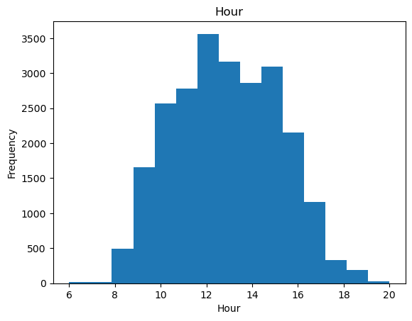

```python
hour_hist = data.hist(column="Hour", bins=15, grid=False)

for ax in hour_hist.flatten():
    ax.set_xlabel("Hour")
    ax.set_ylabel("Frequency")
```

Apriori Algorithm

```python
# import apyori
from apyori import apriori
```

Data Preprocessing

```python
items_df=data[data.columns[3:44]]
```

```python
items_df.head()
```

|  | item_0 | item_1 | item_2 | item_3 | item_4 | item_5 | item_6 | item_7 | item_8 | item_9 | ... | item_31 | item_32 | item_33 | item_34 | item_35 | item_36 | item_37 | item_38 | item_39 | item_40 |
| --- | --- | --- | --- | --- | --- | --- | --- | --- | --- | --- | --- | --- | --- | --- | --- | --- | --- | --- | --- | --- | --- |
| 20945 | Discount | NaN | NaN | NaN | NaN | NaN | NaN | NaN | NaN | NaN | ... | NaN | NaN | NaN | NaN | NaN | NaN | NaN | NaN | NaN | NaN |
| 29035 | WRAP ALPHABET DESIGN | MAGIC DRAWING SLATE CIRCUS PARADE | SET/6 RED SPOTTY PAPER CUPS | TRADITIONAL NAUGHTS & CROSSES | 3D DOG PICTURE PLAYING CARDS | SET 12 RETRO WHITE CHALK STICKS | VINTAGE SNAP CARDS | MINI PLAYING CARDS SPACEBOY | SET/4 BADGES BEETLES | SET/4 BADGES BALLOON GIRL | ... | CHILDRENS TOY COOKING UTENSIL SET | LANDMARK FRAME CAMDEN TOWN | RED HARMONICA IN BOX | WOODEN BOX OF DOMINOES | SET OF 3 REGENCY CAKE TINS | RETROSPOT PARTY BAG + STICKER SET | PAPER CHAIN KIT 50'S CHRISTMAS | 6 GIFT TAGS 50'S CHRISTMAS | RATTLE SNAKE EGGS | NaN |
| 21727 | VINTAGE CHRISTMAS CAKE FRILL | VINTAGE CHRISTMAS BUNTING | SET 7 BABUSHKA NESTING BOXES | ROLL WRAP VINTAGE SPOT | ROLL WRAP VINTAGE CHRISTMAS | ZINC FOLKART SLEIGH BELLS | WOODLAND BUNNIES LOLLY MAKERS | ICE CREAM BUBBLES | RED SPOT GIFT BAG LARGE | SPACEBOY ROCKET LOLLY MAKERS | ... | PARTY BUNTING | SPOTTY BUNTING | NaN | NaN | NaN | NaN | NaN | NaN | NaN | NaN |
| 27645 | OFFICE MUG WARMER CHOC+BLUE | CHRISTMAS PUDDING TRINKET POT | PINK DOUGHNUT TRINKET POT | VINTAGE BILLBOARD LOVE/HATE MUG | SAVE THE PLANET MUG | LOCAL CAFE MUG | PLASTERS IN TIN SKULLS | GROOVY CACTUS INFLATABLE | ICE CREAM BUBBLES | MAGIC TREE -PAPER FLOWERS | ... | NaN | NaN | NaN | NaN | NaN | NaN | NaN | NaN | NaN | NaN |
| 30947 | SNACK TRAY I LOVE LONDON | SNACK TRAY HAPPY FOREST | VINTAGE DOILY JUMBO BAG RED | SET 10 CARD KRAFT REINDEER 17084 | SET 6 CARDS SPARKLY REINDEER 17262 | SET 10 CARDS DINKY TREE 17076 | LUNCH BAG RED VINTAGE DOILY | PAISLEY PARK CARD | DOILY THANK YOU CARD | BLUE VICTORIAN FABRIC OVAL BOX | ... | KITCHEN METAL SIGN | BATHROOM METAL SIGN | AREA PATROLLED METAL SIGN | N0 SINGING METAL SIGN | METAL SIGN,CUPCAKE SINGLE HOOK | METAL SIGN,CUPCAKE SINGLE HOOK | FRAPPUCINO SCARF KNITTING KIT | MIDNIGHT GLAMOUR SCARF KNITTING KIT | KNITTED UNION FLAG HOT WATER BOTTLE | ENGLISH ROSE HOT WATER BOTTLE |

5 rows × 41 columns

```python
baskets = items_df.T.apply(lambda x: x.dropna().tolist()).tolist()
```

```python
for i in baskets [:5]:
    print(i)
```

```
['Discount']
['WRAP ALPHABET DESIGN', 'MAGIC DRAWING SLATE CIRCUS PARADE', 'SET/6 RED SPOTTY PAPER CUPS', 'TRADITIONAL NAUGHTS & CROSSES', '3D DOG PICTURE PLAYING CARDS', 'SET 12 RETRO WHITE CHALK STICKS', 'VINTAGE SNAP CARDS', 'MINI PLAYING CARDS SPACEBOY', 'SET/4 BADGES BEETLES', 'SET/4 BADGES BALLOON GIRL', '…
['VINTAGE CHRISTMAS CAKE FRILL', 'VINTAGE CHRISTMAS BUNTING', 'SET 7 BABUSHKA NESTING BOXES', 'ROLL WRAP VINTAGE SPOT', 'ROLL WRAP VINTAGE CHRISTMAS', 'ZINC FOLKART SLEIGH BELLS', 'WOODLAND BUNNIES LOLLY MAKERS', 'ICE CREAM BUBBLES', 'RED SPOT GIFT BAG LARGE', 'SPACEBOY ROCKET LOLLY MAKERS', 'SET OF…
['OFFICE MUG WARMER CHOC+BLUE', 'CHRISTMAS PUDDING TRINKET POT', 'PINK DOUGHNUT TRINKET POT', 'VINTAGE BILLBOARD LOVE/HATE MUG', 'SAVE THE PLANET MUG', 'LOCAL CAFE MUG', 'PLASTERS IN TIN SKULLS', 'GROOVY CACTUS INFLATABLE', 'ICE CREAM BUBBLES', 'MAGIC TREE -PAPER FLOWERS', 'MAGIC SHEEP WOOL GROWING …
['SNACK TRAY I LOVE LONDON', 'SNACK TRAY HAPPY FOREST', 'VINTAGE DOILY JUMBO BAG RED', 'SET 10 CARD KRAFT REINDEER 17084', 'SET 6 CARDS SPARKLY REINDEER 17262', 'SET 10 CARDS DINKY TREE 17076', 'LUNCH BAG RED VINTAGE DOILY', 'PAISLEY PARK CARD', 'DOILY THANK YOU CARD', 'BLUE VICTORIAN FABRIC OVAL BO…
```

```python
association_rules = apriori(baskets, min_support=0.01, min_confidence=0.2,
min_lift=3, min_length=2)
association_results = list(association_rules)
```

```python
print('Rules generated: ', len(association_results))
```

```
Rules generated:  80
```

```python
print(association_results[0])
```

```
RelationRecord(items=frozenset({'60 TEATIME FAIRY CAKE CASES', 'PACK OF 72 RETROSPOT CAKE CASES'}), support=0.010634762379528082, ordered_statistics=[OrderedStatistic(items_base=frozenset({'60 TEATIME FAIRY CAKE CASES'}), items_add=frozenset({'PACK OF 72 RETROSPOT CAKE CASES'}), confidence=0.3975155…
```

```python
print(association_results[1])
```

```
RelationRecord(items=frozenset({'ALARM CLOCK BAKELIKE GREEN', 'ALARM CLOCK BAKELIKE PINK'}), support=0.012545696244599535, ordered_statistics=[OrderedStatistic(items_base=frozenset({'ALARM CLOCK BAKELIKE GREEN'}), items_add=frozenset({'ALARM CLOCK BAKELIKE PINK'}), confidence=0.3952879581151833, lif…
```

```python
def display_rules(association_results):

    for item in association_results:

        pair = item[0]
        items = [x for x in pair]

        print("Rule: " + items[0] + " -> " + items[1])
        print("Support: " + str(item[1]))
        print("Confidence: " + str(item[2][0][2]))
        print("Lift: " + str(item[2][0][3]))
        print("=====================================")
```

```python
display_rules(association_results[:10])
```

```
Rule: 60 TEATIME FAIRY CAKE CASES -> PACK OF 72 RETROSPOT CAKE CASES
Support: 0.010634762379528082
Confidence: 0.39751552795031053
Lift: 9.665650291737247
=====================================
Rule: ALARM CLOCK BAKELIKE GREEN -> ALARM CLOCK BAKELIKE PINK
Support: 0.012545696244599535
Confidence: 0.3952879581151833
Lift: 17.113977927605564
=====================================
Rule: ALARM CLOCK BAKELIKE GREEN -> ALARM CLOCK BAKELIKE RED
Support: 0.019233964772349618
Confidence: 0.606020942408377
Lift: 19.04456413270816
=====================================
Rule: ALARM CLOCK BAKELIKE PINK -> ALARM CLOCK BAKELIKE RED
Support: 0.01325191093386507
Confidence: 0.5737410071942446
Lift: 18.030148205195633
=====================================
Rule: BAKING SET 9 PIECE RETROSPOT -> BAKING SET SPACEBOY DESIGN
Support: 0.01005317381189764
Confidence: 0.33060109289617484
Lift: 20.510900794321444
=====================================
Rule: CHARLOTTE BAG PINK POLKADOT -> CHARLOTTE BAG SUKI DESIGN
Support: 0.01192256563642406
Confidence: 0.5344506517690876
Lift: 19.884538005232574
=====================================
Rule: RED RETROSPOT CHARLOTTE BAG -> CHARLOTTE BAG PINK POLKADOT
Support: 0.01005317381189764
Confidence: 0.45065176908752325
Lift: 13.997534690935302
=====================================
Rule: HOT WATER BOTTLE TEA AND SYMPATHY -> CHOCOLATE HOT WATER BOTTLE
Support: 0.010717846460618146
Confidence: 0.3897280966767372
Lift: 19.26393171088792
=====================================
Rule: SCOTTIE DOG HOT WATER BOTTLE -> CHOCOLATE HOT WATER BOTTLE
Support: 0.010676304420073114
Confidence: 0.3882175226586103
Lift: 15.653554782978338
=====================================
Rule: DOLLY GIRL LUNCH BOX -> SPACEBOY LUNCH BOX
Support: 0.016367563974742438
Confidence: 0.6042944785276073
Lift: 22.413831567205797
=====================================
```

```python
from collections import Counter

counter = Counter(baskets[0])
for i in baskets[1:]:
    if i != 'nan':
        counter.update(i)

del counter['nan']
counter.most_common(10)
```

```
[('WHITE HANGING HEART T-LIGHT HOLDER', 1810),
 ('JUMBO BAG RED RETROSPOT', 1615),
 ('REGENCY CAKESTAND 3 TIER', 1591),
 ('PARTY BUNTING', 1307),
 ('LUNCH BAG RED RETROSPOT', 1231),
 ('ASSORTED COLOUR BIRD ORNAMENT', 1178),
 ('SET OF 3 CAKE TINS PANTRY DESIGN', 1070),
 ('PACK OF 72 RETROSPOT CAKE CASES', 1016),
 ('POSTAGE', 996),
 ('LUNCH BAG  BLACK SKULL', 983)]
```

Q4. How many of these items can you find in the rules you have just displayed? Are all the top 10 items included? Provide an explanation as to why these items may be missing/present in the rules.

Only 1 item 'PACK OF 72 RETROSPOT CAKE CASES' appeared in the rules. The rest 9 items are not included in the rule. In Apriori association rule mining, the most frequent items may not appear in the final rules due to several factors. First, combinations involving these items might not meet the minimum support threshold. Second, the confidence of the rules generated with these items may be below the required minimum confidence level. Additionally, frequent items may not strongly associate with other items, leading to lower confidence in potential rules. Finally, the algorithm often prunes redundant or trivial rules, excluding those involving frequent items if they do not provide new or significant insights.

Q5. Run the apriori algorithm with the following three different settings: Setting 1: Min Support = 0.015, Min Confidence = 0.7, Min Lift = 3 Setting 2: Min Support = 0.009, Min Confidence = 0.5, Min Lift = 3 Setting 3: Min Support = 0.015, Min Confidence = 0.5, Min Lift = 9

Setting 1: Min Support = 0.015, Min Confidence = 0.7, Min Lift = 3

```python
association_rules1 = apriori(baskets, min_support=0.015, min_confidence=0.7,
min_lift=3, min_length=2)
association_results1 = list(association_rules1)
```

```python
print('Rules generated - Setting1: ', len(association_results1))
```

```
Rules generated - Setting1:  4
```

```python
display_rules(association_results1)
```

```
Rule: GREEN REGENCY TEACUP AND SAUCER -> PINK REGENCY TEACUP AND SAUCER
Support: 0.019233964772349618
Confidence: 0.7807757166947724
Lift: 23.8513109800464
=====================================
Rule: GREEN REGENCY TEACUP AND SAUCER -> ROSES REGENCY TEACUP AND SAUCER
Support: 0.023305084745762712
Confidence: 0.7119289340101523
Lift: 20.772791878172587
=====================================
Rule: PINK REGENCY TEACUP AND SAUCER -> ROSES REGENCY TEACUP AND SAUCER
Support: 0.018444666001994018
Confidence: 0.748735244519393
Lift: 21.84673309826767
=====================================
Rule: GREEN REGENCY TEACUP AND SAUCER -> PINK REGENCY TEACUP AND SAUCER
Support: 0.015952143569292122
Confidence: 0.8293736501079914
Lift: 24.19961515806008
=====================================
```

Setting 2: Min Support = 0.009, Min Confidence = 0.5, Min Lift = 3

```python
association_rules2 = apriori(baskets, min_support=0.009, min_confidence=0.5,
min_lift=3, min_length=2)
association_results2 = list(association_rules2)
```

```python
print('Rules generated - Setting2: ', len(association_results2))
```

```
Rules generated - Setting2:  46
```

```python
display_rules(association_results2[:10])
```

```
Rule: ALARM CLOCK BAKELIKE GREEN -> ALARM CLOCK BAKELIKE IVORY
Support: 0.009346959122632104
Confidence: 0.5382775119617226
Lift: 16.959968937097624
=====================================
Rule: ALARM CLOCK BAKELIKE GREEN -> ALARM CLOCK BAKELIKE PINK
Support: 0.012545696244599535
Confidence: 0.5431654676258993
Lift: 17.11397792760556
=====================================
Rule: ALARM CLOCK BAKELIKE GREEN -> ALARM CLOCK BAKELIKE RED
Support: 0.019233964772349618
Confidence: 0.606020942408377
Lift: 19.04456413270816
=====================================
Rule: ALARM CLOCK BAKELIKE IVORY -> ALARM CLOCK BAKELIKE RED
Support: 0.00976237952808242
Confidence: 0.562200956937799
Lift: 17.667495346483943
=====================================
Rule: ALARM CLOCK BAKELIKE RED -> ALARM CLOCK BAKELIKE ORANGE
Support: 0.009430043203722167
Confidence: 0.6676470588235294
Lift: 20.981201044386424
=====================================
Rule: ALARM CLOCK BAKELIKE PINK -> ALARM CLOCK BAKELIKE RED
Support: 0.01325191093386507
Confidence: 0.5737410071942446
Lift: 18.030148205195633
=====================================
Rule: BAKING SET 9 PIECE RETROSPOT -> BAKING SET SPACEBOY DESIGN
Support: 0.01005317381189764
Confidence: 0.6237113402061855
Lift: 20.510900794321444
=====================================
Rule: TOILET METAL SIGN -> BATHROOM METAL SIGN
Support: 0.009139248919906947
Confidence: 0.7006369426751593
Lift: 32.12520473157416
=====================================
Rule: RED  HARMONICA IN BOX -> BLUE HARMONICA IN BOX
Support: 0.009679295446992356
Confidence: 0.5259593679458239
Lift: 24.254586025271784
=====================================
Rule: BLUE STRIPE CERAMIC DRAWER KNOB -> RED STRIPE CERAMIC DRAWER KNOB
Support: 0.009014622798271851
Confidence: 0.5961538461538461
Lift: 39.86282051282051
=====================================
```

Setting 3: Min Support = 0.015, Min Confidence = 0.5, Min Lift = 9

```python
association_rules3 = apriori(baskets, min_support=0.015, min_confidence=0.5,
min_lift=9, min_length=2)
association_results3 = list(association_rules3)
```

```python
print('Rules generated - Setting3: ', len(association_results3))
```

```
Rules generated - Setting3:  9
```

```python
display_rules(association_results3)
```

```
Rule: ALARM CLOCK BAKELIKE GREEN -> ALARM CLOCK BAKELIKE RED
Support: 0.019233964772349618
Confidence: 0.606020942408377
Lift: 19.04456413270816
=====================================
Rule: DOLLY GIRL LUNCH BOX -> SPACEBOY LUNCH BOX
Support: 0.016367563974742438
Confidence: 0.6042944785276073
Lift: 22.413831567205797
=====================================
Rule: GARDENERS KNEELING PAD KEEP CALM -> GARDENERS KNEELING PAD CUP OF TEA
Support: 0.015619807244931871
Confidence: 0.656195462478185
Lift: 23.026147482179113
=====================================
Rule: GREEN REGENCY TEACUP AND SAUCER -> PINK REGENCY TEACUP AND SAUCER
Support: 0.019233964772349618
Confidence: 0.5875634517766498
Lift: 23.8513109800464
=====================================
Rule: GREEN REGENCY TEACUP AND SAUCER -> ROSES REGENCY TEACUP AND SAUCER
Support: 0.023305084745762712
Confidence: 0.7119289340101523
Lift: 20.772791878172587
=====================================
Rule: PINK REGENCY TEACUP AND SAUCER -> ROSES REGENCY TEACUP AND SAUCER
Support: 0.018444666001994018
Confidence: 0.748735244519393
Lift: 21.84673309826767
=====================================
Rule: WOODLAND CHARLOTTE BAG -> RED RETROSPOT CHARLOTTE BAG
Support: 0.015245928880026587
Confidence: 0.5779527559055118
Lift: 17.95158547117094
=====================================
Rule: WOODEN FRAME ANTIQUE WHITE -> WOODEN PICTURE FRAME WHITE FINISH
Support: 0.01715686274509804
Confidence: 0.528809218950064
Lift: 15.011197545478705
=====================================
Rule: GREEN REGENCY TEACUP AND SAUCER -> PINK REGENCY TEACUP AND SAUCER
Support: 0.015952143569292122
Confidence: 0.6475548060708263
Lift: 27.785988042311818
=====================================
```

Sum up

- Rules generated - Setting1: 4 --> Min Support = 0.015, Min Confidence = 0.7, Min Lift = 3
- Rules generated - Setting2: 46 --> Min Support = 0.009, Min Confidence = 0.5, Min Lift = 3
- Rules generated - Setting3: 9 --> Min Support = 0.015, Min Confidence = 0.5, Min Lift = 9

To see the effect of Lift and confidence, we need to use control variable method and run more expriments.

Check the effect of Confidence. We maintain the same value of support as 0.015, same Lift as 3, run confidence as 0.0003 amd 0.9.

```python
association_rules_new1 = apriori(baskets, min_support=0.015, min_confidence=0.0003,
min_lift=3, min_length=2)
association_results_new1 = list(association_rules_new1)
print('Rules generated - confidence 0.003: ', len(association_results_new1 ))
```

```
Rules generated - confidence 0.003:  15
```

```python
association_rules_new2 = apriori(baskets, min_support=0.015, min_confidence=0.9,
min_lift=3, min_length=2)
association_results_new2 = list(association_rules_new2)
print('Rules generated - confidence 0.9: ', len(association_results_new2))
```

```
Rules generated - confidence 0.9:  0
```

Larger Confidence threhold results in smaller amount of rules generated.

High Confidence Threshold: Ensures that the rules generated are reliable and have strong associations, increasing their usefulness. However, it may exclude some valid but less confident rules, reducing comprehensiveness.

Now we check the effect of Lift, also use control variable method. We set support value as 0.015, confidence as 0.3, change Lift between 3 and 9.

```python
association_rules_new3 = apriori(baskets, min_support=0.015, min_confidence=0.3,
min_lift=3, min_length=2)
association_results_new3 = list(association_rules_new3)
print('Rules generated - Lift 3: ', len(association_results_new3))
```

```
Rules generated - Lift 3:  15
```

```python
association_rules_new4 = apriori(baskets, min_support=0.015, min_confidence=0.3,
min_lift=9, min_length=2)
association_results_new4 = list(association_rules_new4)
print('Rules generated - Lift 9: ', len(association_results_new4))
```

```
Rules generated - Lift 9:  11
```

Ligher lift value generates lower number of rules.

High Lift Threshold: Focuses on rules that provide more significant insights beyond random chance, enhancing usefulness by filtering out less meaningful associations. However, it may limit the number of rules, affecting comprehensiveness.

Q6. Filter the transactions from the day of the week or the month and generate association rules again. Discuss whether the rules change in different days or different months.

We select and filter all the records of first day of each month 01/xx/xxx

```python
data['Date'] = pd.to_datetime(df['Date'], format='%d/%m/%Y')
first_day = data[data['Date'].dt.day == 1]
print(first_day.head())
print(first_day.shape)
```

```
      transaction_ID       Date   Time                            item_0  \
30650         579954 2011-12-01  11:10    IVORY RETRO KITCHEN WALL CLOCK
30623        C579924 2011-12-01  09:13      CLASSIC CAFE SUGAR DISPENSER
10529         551517 2011-05-01  11:14    SET OF 9 HEART SHAPED BALLOONS
13034        C555197 2011-06-01  11:45  HANGING HEART JAR T-LIGHT HOLDER
4573          542919 2011-02-01  16:47           RECYCLING BAG RETROSPOT

                              item_1                           item_2  \
30650        WRAP KEEP CALM BIRTHDAY          MIRRORED WALL ART STARS
30623                            NaN                              NaN
10529  DOORMAT VINTAGE LEAVES DESIGN  BOHEMIAN COLLAGE STATIONERY SET
13034                            NaN                              NaN
4573             WALL TIDY RETROSPOT             BOTTLE BAG RETROSPOT

                                item_3                               item_4  \
```

[output cut: 50 more lines]

```python
items1_df = first_day[first_day.columns[3:44]]
```

```python
items1_df.head()
```

|  | item_0 | item_1 | item_2 | item_3 | item_4 | item_5 | item_6 | item_7 | item_8 | item_9 | ... | item_31 | item_32 | item_33 | item_34 | item_35 | item_36 | item_37 | item_38 | item_39 | item_40 |
| --- | --- | --- | --- | --- | --- | --- | --- | --- | --- | --- | --- | --- | --- | --- | --- | --- | --- | --- | --- | --- | --- |
| 30650 | IVORY RETRO KITCHEN WALL CLOCK | WRAP KEEP CALM BIRTHDAY | MIRRORED WALL ART STARS | MIRRORED WALL ART POPPIES | MIRRORED WALL ART SNOWFLAKES | MIRRORED WALL ART SKULLS | JIGSAW TOADSTOOLS 3 PIECE | JIGSAW RABBIT AND BIRDHOUSE | SET OF 60 I LOVE LONDON CAKE CASES | RED RETROSPOT MINI CASES | ... | NaN | NaN | NaN | NaN | NaN | NaN | NaN | NaN | NaN | NaN |
| 30623 | CLASSIC CAFE SUGAR DISPENSER | NaN | NaN | NaN | NaN | NaN | NaN | NaN | NaN | NaN | ... | NaN | NaN | NaN | NaN | NaN | NaN | NaN | NaN | NaN | NaN |
| 10529 | SET OF 9 HEART SHAPED BALLOONS | DOORMAT VINTAGE LEAVES DESIGN | BOHEMIAN COLLAGE STATIONERY SET | JARDIN ETCHED GLASS CHEESE DISH | CLEAR DRAWER KNOB ACRYLIC EDWARDIAN | FELTCRAFT 6 FLOWER FRIENDS | HEADS AND TAILS SPORTING FUN | TRADITIONAL WOODEN CATCH CUP GAME | ASSORTED COLOUR BIRD ORNAMENT | CALENDAR PAPER CUT DESIGN | ... | TUMBLER NEW ENGLAND | WATERING CAN PINK BUNNY | WATERING CAN GREEN DINOSAUR | WATERING CAN BLUE ELEPHANT | S/4 PINK FLOWER CANDLES IN BOWL | FLORAL FOLK STATIONERY SET | SET OF 4 ENGLISH ROSE COASTERS | POTTING SHED TEA MUG | SAVE THE PLANET MUG | JARDIN ETCHED GLASS FRUITBOWL |
| 13034 | HANGING HEART JAR T-LIGHT HOLDER | NaN | NaN | NaN | NaN | NaN | NaN | NaN | NaN | NaN | ... | NaN | NaN | NaN | NaN | NaN | NaN | NaN | NaN | NaN | NaN |
| 4573 | RECYCLING BAG RETROSPOT | WALL TIDY RETROSPOT | BOTTLE BAG RETROSPOT | JUMBO BAG RED RETROSPOT | NaN | NaN | NaN | NaN | NaN | NaN | ... | NaN | NaN | NaN | NaN | NaN | NaN | NaN | NaN | NaN | NaN |

5 rows × 41 columns

```python
baskets1 = items1_df.T.apply(lambda x: x.dropna().tolist()).tolist()
```

```python
association_rules_firstday = apriori(baskets, min_support=0.009, min_confidence=0.5,
min_lift=3, min_length=2)
association_results_firstday = list(association_rules_firstday)
print('Rules generated - firstday: ', len(association_results_firstday))
```

```
Rules generated - firstday:  46
```

```python
display_rules(association_results_firstday[:10])
```

[output not shown]

Analysis of the rules generated from filtered firstday of each month dataset and the whole dataset